# R Dataframes

## Dataframe: nc

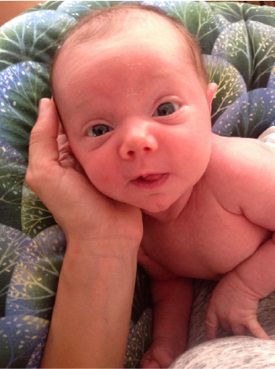

```r
download.file("http://www.openintro.org/stat/data/nc.RData",
              destfile = "nc.RData")
load("nc.RData")
```

- What are the dimensions?
- What mode of data is in each column? (`head()`)

## Dataframe: nc

```r
class(nc)
```

```
## [1] "data.frame"
```

```r
dim(nc)
```

```
## [1] 1000   13
```

```r
length(nc)
```

```
## [1] 13
```

## Dataframes

1. What `attributes()` does this dataframe have?
2. What happens when you convert this dataframe into a matrix?

## Subsetting columns

`$` is an operator used to access a column (vector) from a dataframe.

```r
head(nc$fage)
```

```
## [1] NA NA 19 21 NA NA
```

```r
length(nc$fage)
```

```
## [1] 1000
```

It can be subsetted just like a vector.

```r
nc$fage[3]
```

```
## [1] 19
```

## Subsetting as a matrix

You can also subset the whole dataframe like a matrix. What do you think the following commands do?

```r
nc[1:10, 1:2]
nc[1, ]
nc[nc$gender == "female", "premie"]
```

Note that the last command could be written also using vector subsetting.

```r
nc$premie[nc$gender == "female"]
```

## Two ways to subset

1. **Subset by index**: specify inside the square bracks exactly which elements you want.

   ```r
   nc$gender[1:10]
   ```

2. **Subset by logical**: specify conditions inside brackets with logical operators that will evaluate to a T/F vector of the same length as that being subsetted.

   ```r
   nc$gender[nc$premie == "premie"]
   ```

   Note that the vector that you're using to specify the condition can be different from the one you're subsetting, but it has to be of the same length.

## Functions on vectors

There are many statistical functions that take a vector as an argument (`mean()`, `sum()`, `median()`, `sd()`, `max()`, `min()`, etc.) that can also be used to subset.

```r
nc[nc$mage == max(nc$mage), ]
```

```
##      fage mage     mature weeks    premie visits     marital gained weight
## 1000   45   50 mature mom    39 full term     14 not married     23   7.13
##      lowbirthweight gender     habit whitemom
## 1000        not low female nonsmoker    white
```

Fix the following subsetting errors using data from `nc`.

```r
nc[nc$visits = 4, ]
nc[-1:4, ]
nc[nc$visits <= 5]
nc[nc$visits == 4 | 6, ]
```